# Aproximación estocástica

### Algoritmo de Robbins-Monro

El algoritmo de Robbins-Monro sirve para resolver el problema de encontrar la raíz de una función $\pmb{h}\,:\,\mathbb{R}^d\to\mathbb{R}^d$, es decir encontrar $\pmb{\theta}^\star$ tal que $\pmb{h}(\pmb{\theta}^\star)=\pmb{0}$, en el caso en que no podemos evaluar directamente la función $h$ pero tenemos acceso a un proceso estocástico $\pmb{H}$ tal que para $\pmb{\theta}\in\mathbb{R}^d$ $\mathbb{E}\left[\pmb{H}(\pmb{\theta})\right]=\pmb{h}(\pmb{\theta})$. Más precisamente el algoritmo de Robbins-Monro es un esquema iterativo para encontrar $\pmb{\theta}^\star$ dado por

$$ \pmb{\theta}_n=\pmb{\theta}_{n-1} - \gamma_{n-1} \pmb{H}(\pmb{\theta}_{n-1}) $$

donde $\gamma_n$ puede ser una v.a. que puede depender de $ \pmb{\theta}_0,\pmb{H}_0, \dots , \pmb{\theta}_n,\pmb{H}_n$ con $\pmb{H}_i=\pmb{H}(\pmb{\theta}_i)$, $0\leq i$.

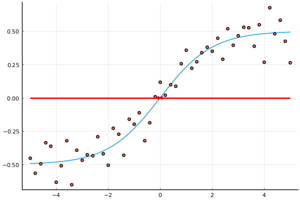

```julia
p
```

### Teorema convergencia de Robbins-Monro

Si

1) La función $\pmb{h}$ tiene una única raiz $\pmb{\theta}^\star$.

2) Para $\pmb{\theta}\in\mathbb{R}^d$ se tiene que $\left( \pmb{\theta}-\pmb{\theta}^\star\right) \odot \pmb{h}(\pmb{\theta})\geq\pmb{0}$.

3) Para $g\,:\,\mathbb{R}^d\to\mathbb{R}$ dada por $g(\pmb{\theta})=\mathbb{E}\left[ \| \pmb{H}(\pmb{\theta})\| \right]$ se tiene que existen $a,b>0$ tales que

$$g(\pmb{\theta}) \stackrel{\text{c.s.}}{\leq} a + b\| \pmb{\theta} \|.$$

4) $\;\sum_{n=1}^\infty \gamma_n \stackrel{\text{c.s.}}{=} \infty$ y $\sum_{n=1}^\infty \gamma^2_n \stackrel{\text{c.s.}}{<} \infty$.

Entonces $\lim\limits_{n\to \infty} \theta_n \stackrel{\text{c.s.}}{=} \theta^\star$.

La convergencia del esquema iterativo de Robbins-Monro se puede demostrar haciendo uso de ecuaciones diferenciales ordinarias motivadas por la expresión alterna de la iteración $$ \frac{\theta_{n+1}-\theta_n}{\eta_n} = -h(\theta_n) + \epsilon_n, $$

con $\epsilon_n = H_n-h(\theta_n)$ interpretado como un ruido. Lo anterior es similar al esquema de Euler para la ecuación diferencial

$$ \left(\frac{ \mathrm{d} \theta }{\mathrm{d}t}\right)(t) = -h\left( \theta(t) \right). $$

Sin embargo optamos por estudiar la demostración clásica de Robbins y Siegmund (1985) "A convergence theorem for non negative almost supermartingales and some applications".

#### Definiciones preliminares

**Definición 1: Proceso adapatado.** Dada una filtración $\left\{ \mathcal{F}_n \right\}_{n= 0}^\infty$ decimos que una secuencia de v.a.'s $\left\{ V_n \right\}_{n= 0}^\infty$ es $\mathcal{F}_n$-adaptada si para $n\geq 0$ entonces $V_n$ es $\mathcal{F}_n$-medible.

**Definición 2: Proceso predecible.** Dada una filtración $\left\{ \mathcal{F}_n \right\}_{n= 0}^\infty$ decimos que una secuencia de v.a.'s $\left\{ V_n \right\}_{n=0}^\infty$ es $\mathcal{F}_n$-predecible si para $n\geq 1$ entonces $V_n$ es $\mathcal{F}_{n-1}$-medible.

**Definición 3: Súper-martingala.** Dada una filtración $\left\{ \mathcal{F}_n \right\}_{n= 0}^\infty$, decimos que una secuencia de v.a.'s $\left\{ M_n \right\}_{n= 0}^\infty$ es una super-martingala si cada $M_n$ es integrable, i.e. $\mathbb{E}\left[|M_n|\right]<\infty$, y se sastiface que para $n\geq 1$

$$ \mathbb{E}\left[ M_n \,|\, \mathcal{F}_{n-1} \right] \leq M_{n-1} . $$

#### Teorema de Doob

Sea $\left\{ M_n \right\}_{n=0}^\infty$ una supermartingala tal que

$$ \sup_{n\geq 0}\mathbb{E}\left[ -\min\left\{ M_n,0 \right\} \right]<\infty $$

emtonces existe $ M_\infty \stackrel{\text{c.s.}}{=} \lim_{n\to\infty}M_n $ tal que $\mathbb{E}\left[ M_\infty \right]<\infty$.

### Teorema de Robbins-Siegmund

Sea $\left\{ \mathcal{F}_n \right\}_{n=0}^\infty$ una filtración y cuatro secuencias de v.a.'s $\left\{ V_n \right\}_{n=0}^\infty,\left\{ U_n \right\}_{n=0}^\infty,\left\{ \alpha_n \right\}_{n=0}^\infty,\left\{ \beta_n \right\}_{n=0}^\infty$ no negativas, $\mathcal{F}_n$-adaptas e integrables tales que

1) $\left\{ U_n \right\}_{n=0}^\infty,\left\{ \alpha_n \right\}_{n=0}^\infty$, y $\left\{ \beta_n \right\}_{n=0}^\infty$ son $\mathcal{F}_n$-predecibles.

2) $\sum_{n=0}^\infty \alpha_n \stackrel{\text{c.s.}}{<} \infty$ y $\sum_{n=0}^\infty \beta_n \stackrel{\text{c.s.}}{<} \infty$.

3) Para todo $n\geq 1$ $$\mathbb{E}\left[ V_n \,|\, \mathcal{F}_{n-1} \right] \leq V_{n-1}(1+\alpha_n) + \beta_n - U_n.$$

Entonces existe $ V_\infty \stackrel{\text{c.s.}}{=} \lim_{n\to\infty}V_n $ y $\sum_{n=0}^\infty U_n <\infty$.

La idea de la prueba es construir una super-martingala auxiliar para utilizar el teorema de Doob y concluir el resultado. Primero observamos que $\left\{ U_n \right\}_{n\leq 0}$ predecible implica

\begin{align*} \mathbb{E}\left[ V_n + \sum_{k=0}^n (U_k-\beta_k) \,\Bigg|\, \mathcal{F}_{n-1} \right] \leq V_{n-1}(1+\alpha_n) + \sum_{k=0}^{n-1} (U_k-\beta_k) \leq \left( V_{n-1} + \sum_{k=0}^{n-1} (U_k-\beta_k) \right)(1+\alpha_n). \end{align*}

Entonces definimos

$$ M_n = \frac{ V_n + \sum_{k=0}^n (U_k-\beta_k) }{\prod_{k=0}^n (1+\alpha_k)} $$

con lo cual

\begin{align*} \mathbb{E}\left[ M_n \,|\, \mathcal{F}_{n-1} \right] = \mathbb{E}\left[ \frac{ V_n + \sum_{k=0}^n (U_k-\beta_k) }{\prod_{k=0}^n (1+\alpha_k)} \,\Bigg|\, \mathcal{F}_{n-1} \right] \leq \frac{V_{n-1} + \sum_{k=0}^{n-1} (U_k-\beta_k) }{\prod_{k=0}^{n-1} (1+\alpha_k)} = M_{n-1} \end{align*}

**Definición 4: Tiempo de paro.** Dada una filtración $\left\{ \mathcal{F}_n \right\}_{n= 0}^\infty$, decimos que una v.a. $\tau$ que toma valores en $\mathbb{N}\cup\left\{\infty\right\}$ es un tiempo de paro respecto a la filtración si

$$ \left\{ \tau=n \right\} \in \mathcal{F}_n \forall n\in\mathbb{N}. $$

Si $\tau$ es tiempo de paro entonces

\begin{align*} \mathbb{E}\left[ M_{\tau\wedge n}\,|\, \mathcal{F}_{n-1} \right] &= M_{\tau}\pmb{1}\left\{ \tau\leq n-1\right\} +\mathbb{E}\left[ M_{ n}\,|\, \mathcal{F}_{n-1} \right]\pmb{1}\left\{ \tau > n-1\right\} \\ & \leq M_{\tau}\pmb{1}\left\{ \tau\leq n-1\right\} + M_{n-1}\pmb{1}\left\{ \tau > n-1\right\} = M_{\tau\wedge n}. \end{align*}

Para $v>0$ definimos el tiempo de paro

$$ \tau_v = \inf\left\{ n\geq 0 \,:\, \sum_{k=0}^n \beta_k > v \right\} $$

con lo cual

$$ \mathbb{E}\left[ -\min\left\{ M_{\tau_v \wedge n},0\right\} \right] \leq \mathbb{E}\left[ -\min\left\{ V_{ \tau_v\wedge n} + \sum_{k=1}^{\tau_v\wedge n} (U_k-\beta_k) ,0\right\} \right] \leq \mathbb{E}\left[ \sum_{k=1}^{\tau_v\wedge n} \beta_k \right] \leq v <\infty $$

por lo que el teorema de Doob implica que existe $M_\infty \stackrel{\text{c.s.}}{=} \lim_{n\to\infty}M_{\tau_v \wedge n}<\infty$. Observamos que en $\left\{\tau_v \stackrel{c.s.}{=}\infty\right\} =\left\{ \sum_{k=1}^n \beta_k \stackrel{c.s.}{\leq} v \right\} $ se tiene que $M_\infty \stackrel{\text{c.s.}}{=} \lim_{n\to\infty}M_n$ pero al ser $v$ arbitrario y por hipótesis $\sum_{n=0}^\infty \beta_n \stackrel{\text{c.s.}}{<} \infty$ concluimos que se tiene el límite c.s. para $M_n$.

Observamos que por hipótesis

$$ 0\leq \lim_{n\to\infty} \left(\prod_{k=0}^n(1+\alpha_k) \right)\leq \exp\left( \sum_{k=0}^\infty \alpha_n \right) \stackrel{\text{c.s.}}{<} \infty $$

Con lo que al existir $M_\infty$ se sigue que existen los limites $ V_\infty \stackrel{\text{c.s.}}{=} \lim_{n\to\infty}V_n $ y $\sum_{n=0}^\infty U_n <\infty$.

#### Dem. teo. convergencia Robbins-Monro

Con el esquema iterativo de Robbins-Monro, sea $V_n=\|\pmb{\theta}_n-\pmb{\theta}^\star\|^2$ entonces

$$ V_n = \|\pmb{\theta}_{n-1}-\pmb{\theta}^\star -\gamma_{n-1} \pmb{H}_{n-1} \|^2 = V_{n-1} +\gamma_{n-1}^2\|\pmb{H}_{n-1}\|^2 -2\gamma_{n-1}(\pmb{\theta}_{n-1}-\pmb{\theta}^\star)'\pmb{H}_{n-1}, $$

entonces aplicando esperanza y denotando $|\pmb{v}|=(|v_1|,\ldots, |v_d|)$

\begin{align*} \mathbb{E}\left[ V_n \,|\, \mathcal{F}_{n-1}\right] &= V_{n-1} +\gamma_{n-1}^2 \mathbb{E}\left[ \|\pmb{H}_{n-1}\|^2 \,|\, \mathcal{F}_{n-1}\right] -2\gamma_{n-1}(\pmb{\theta}_{n-1}-\pmb{\theta}^\star)'\mathbb{E}\left[\pmb{H}_{n-1} \,|\, \mathcal{F}_{n-1}\right] \\ & = V_{n-1} +\gamma_{n-1}^2 \mathbb{E}\left[ \|\pmb{H}_{n-1}\|^2 \right] -2\gamma_{n-1}(\pmb{\theta}_{n-1}-\pmb{\theta}^\star)'\mathbb{E}\left[\pmb{H}_{n-1} \right] \\ & = V_{n-1} +\gamma_{n-1}^2 g(\pmb{\theta}_{n-1}) -2\gamma_{n-1} |(\pmb{\theta}_{n-1}-\pmb{\theta}^\star)|'|\pmb{h}(\pmb{\theta}_{n-1})| \\ & \leq V_{n-1} +\gamma_{n-1}^2\left( a + b\| \pmb{\theta}_{n-1} \|^2 \right) -2\gamma_{n-1}(\pmb{\theta}_{n-1}-\pmb{\theta}^\star)'h(\pmb{\theta}_{n-1}) \end{align*}

Observamos que

\begin{align*} \| \pmb{\theta}_{n-1} \|^2= \| \pmb{\theta}_{n-1} -\pmb{\theta}^\star + \pmb{\theta}^\star\|^2 \leq \left( \| \pmb{\theta}_{n-1} -\pmb{\theta}^\star \| +\| \pmb{\theta}^\star\| \right)^2 \leq 2\left( \| \pmb{\theta}_{n-1} -\pmb{\theta}^\star \|^2 +\| \pmb{\theta}^\star\|^2 \right) = 2 V_{n-1}+2\| \pmb{\theta}^\star\|^2 \end{align*}

por lo cual

\begin{align*} \mathbb{E}\left[ V_n \,|\, \mathcal{F}_{n-1}\right] & \leq V_{n-1} +\gamma_{n-1}^2\left( a + 2b\left(V_{n-1}+\| \pmb{\theta}^\star\|^2\right) \right) -2\gamma_{n-1}|(\pmb{\theta}_{n-1}-\pmb{\theta}^\star)|'|h(\pmb{\theta}_{n-1})| \\ & = V_{n-1}\left( 1+ 2b\gamma_{n-1}^2 \right) +a \gamma_{n-1}^2 -2\gamma_{n-1}|(\pmb{\theta}_{n-1}-\pmb{\theta}^\star)|'|h(\pmb{\theta}_{n-1})| \end{align*}

Aplicamos el teorema de Robbins-Siegmund con $\alpha_n=2b\gamma_{n-1}^2$, $\,\beta_n=a\gamma_{n-1}^2\,$ y $\,U_n=2\gamma_{n-1}|(\pmb{\theta}_{n-1}-\pmb{\theta}^\star)|'|h(\pmb{\theta}_{n-1})|$.

Se sigue que existe $V_\infty \stackrel{\text{c.s.}}{=} \lim\limits_{n\to \infty} V_n \stackrel{\text{c.s.}}{<}\infty$ y $\sum_{k=0}^\infty U_k \stackrel{\text{c.s.}}{<}$.

Veamos que $V_\infty=0$. Supongamos lo contrario, entonces $V_\infty>0$ implica que $\pmb{\theta}_n \stackrel{\text{c.s.}}{\to} \pmb{\theta}^\circ \stackrel{\text{c.s.}}{<}\infty$ con $\pmb{\theta}^\circ \neq \pmb{\theta}^\star$. Se sigue que para $\epsilon>0$ existe $N>0$ y tal que para todo $n\geq N$

$$ \| \pmb{\theta}_{n-1}-\pmb{\theta}^\circ\|\leq \langle\pmb{1},|\pmb{\theta}_{n-1}-\pmb{\theta}^\circ| \rangle <\epsilon $$

sea ${\displaystyle c=\inf_{ \| \pmb{\theta}-\pmb{\theta}^\circ\| <\epsilon } }|(\pmb{\theta}-\pmb{\theta}^\star)|'|h(\pmb{\theta})| $, que existe por ser $h$ sublineal en las hipótesis, entonces

$$ \infty = 2c \sum_{k=N}^\infty \gamma_{n-1} \leq \sum_{k=0}^\infty U_n $$

contradiciendo la conclusión del teorema de Robbins-Siegmund de que $\sum_{k=0}^\infty U_n<\infty$. Concluimos que $V_\infty=0$ y en consecuencia $\lim\limits_{n\to \infty} \theta_n \stackrel{\text{c.s.}}{=} \theta^\star$.

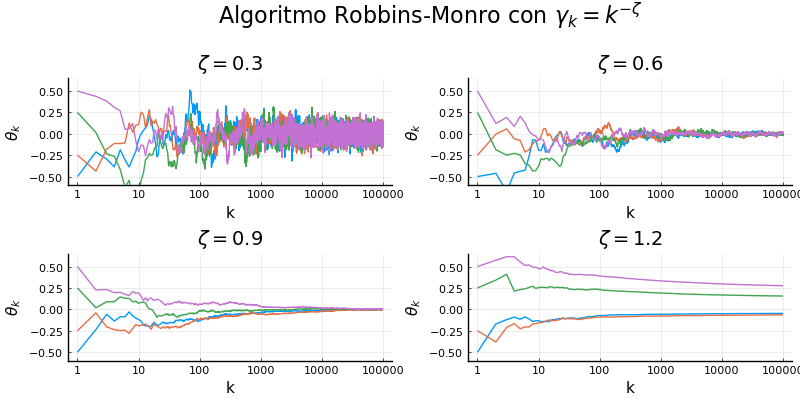

```julia
plt
```

## Decenso estocástico del gradiente

Es usual en el aprendizaje de máquina querer minimizar funciones de la forma

$$ E(\theta) = \sum_{i=1}^n E_i (\theta) $$

para lo cual se busca un cero de la función

$$ \frac{1}{n}\nabla E(\theta) = \frac{1}{n}\sum_{i=1}^n \nabla E_i\theta). $$

El decenso estocástico del gradiente consiste del algoritmo de Robbins-Monro utilizando

\begin{align*} J & \sim \text{Unif}\left\{1,2,\ldots,n\right\} \\ H_{i+1} &= \nabla E_J(\theta_i) \end{align*}

con lo que

$$ h(\theta) = \mathbb{E}\left[ H_{i+1} \,|\, \theta_i = \theta \right] = \frac{1}{n} \sum_{i=1}^n \nabla E_i(\theta). $$

Sea $\pmb{g}:\mathbb{R}^d\to \mathbb{R}^d $ tal que $\mathbb{E}\left[ \pmb{g}(\pmb{\theta}) \right]=\nabla E(\theta)$ entonces el algoritmo de Robbins-Monro para minimiar $E$ está dado por

$$ \pmb{\theta}_{t+1} = \pmb{\theta}_t - \eta_t \pmb{g}(\pmb{\theta}_t) $$

#### Elecciones de decaimeinto para la tasa de aprendizaje

Le elección de decaimiento "óptimo" está dada por

$$ \eta_t = \frac{1}{\alpha(t_0+t)}. $$

Tal esquema de deciamiento es la elección por defecto para SGD en scikit-learn (Septiembre 2024) cuando se considera el problema de clasificacion. El parámetro $t_0$ se elige con una heurística.

Más específicamente

\begin{align*} \pmb{w}_{t+1} & = \pmb{w}_t - \eta_t \left( \alpha \nabla_{\pmb{w}} R(\pmb{w}_t) + \nabla_{\pmb{w}}L(\pmb{w}'_t \pmb{x}_i + b_t, \pmb{y}_i) \right) \\ b_{t+1} & = \pmb{w}_t - \eta_t \left( \frac{ \partial L }{\partial b} (\pmb{w}'_t \pmb{x}_i + b_t, \pmb{y}_i) \right) \end{align*}

con $R$ una función de regularización y $L$ la función de pérdida.

Y se toma

$$ t_0 = \frac{ \alpha^{0.75} }{ \max\left\{ 1, \nabla_{\pmb{w}}L(\pmb{w}'_t \pmb{x}_i + b_t, \pmb{y}_i) \big|_{\pmb{w}=\alpha^{-0.25}\pmb{1},b=1} \right\} } $$

Le elección de decaimiento "de escalamiento inverso" está dada por

$$ \eta_t = \eta_0\big/t^\gamma. $$

También suele usarse el decaimiento constante $\eta_t=\eta_0$ a pesar de la falta de garantías de convergencia; con tal elección se debe de tener cuidado de no terminar oscilando alrededor de un mínimo local.

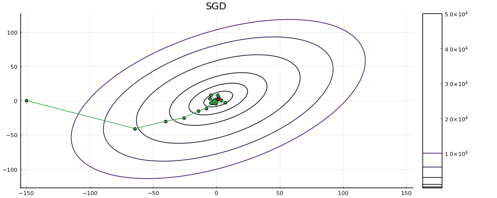

```julia
plt
```

## Promedios de Polyak-Ruppert

Promediar suele reducir la varianza

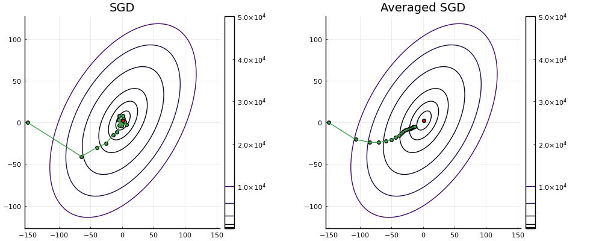

```julia
plot(plt,pltavg)
```

## Momento (Polyak 1964 - Some methods of speeding up the convergence of iteration methods)

\begin{align*} \pmb{\theta}_{t+1} & = \pmb{\theta}_t + \pmb{v}_{t+1} \\ \pmb{v}_{t+1} & = m \pmb{v}_t - \eta_t \pmb{g}(\pmb{\theta}_t) \end{align*}

Entonces \begin{align*} \pmb{\theta}_{t+1} & = \pmb{\theta}_t + m \pmb{v}_t - \eta_t \pmb{g}(\pmb{\theta}_t) \end{align*}

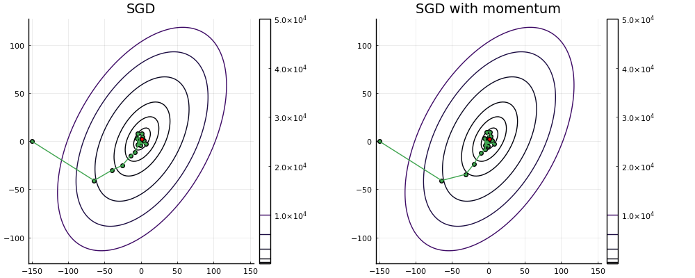

```julia
plot(plt,pltmom)
```

## Momento de Nesterov (Nesterov 1983 - A method of solving a cnvex problem with convergence rate O(1/k²))

\begin{align*} \pmb{\theta}_{t+1} & = \pmb{\theta}_t + \pmb{v}_{t+1} \\ \pmb{v}_{t+1} & = m \pmb{v}_t - \eta_t \pmb{g}\left(\pmb{\theta}_t + m \pmb{v}_t \right) \end{align*}

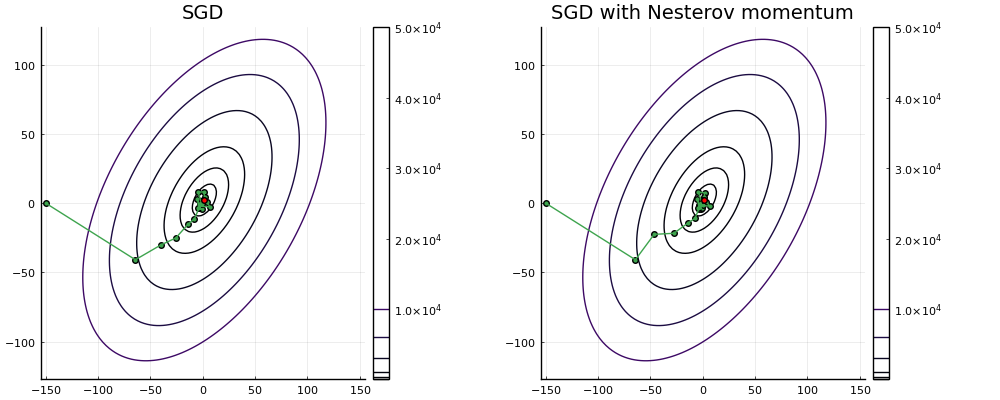

```julia
plot(plt,pltmomnest)
```

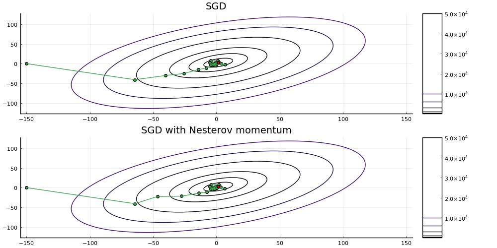

```julia
plot(plt,pltmomnest,layout=(2,1),size=(1000,500))
```

## Adagrad (Duchi et. al 2011 - Adaptive subgradient methods for onlie learning and stochastic optimization)

\begin{align*} \theta_{i,t+1} & = \theta_{i,t} - \frac{ \eta }{ \epsilon + \sqrt{\sum_{j=1}^t \pmb{g}\left( \pmb{\theta}_{j} \right)_i^2 } } \pmb{g}\left( \pmb{\theta}_{t} \right)_i \end{align*}

Alternativamente

\begin{align*} \theta_{i,t+1} & = \theta_{i,t} -\frac{ \eta }{ \epsilon + \sqrt{v_{i,t+1}} } \pmb{g}\left( \pmb{\theta}_t \right)_i \\ v_{i,t+1} & = v_{i,t} + \pmb{g}\left( \pmb{\theta}_t \right)_i^2 \end{align*}

y en forma vectorial

\begin{align*} \pmb{\theta}_{t+1} & = \pmb{\theta}_{t} -\frac{ \eta }{ \epsilon\pmb{1} + \sqrt{\pmb{v}_{t+1}} } \odot \pmb{g}\left( \pmb{\theta}_{t} \right) \\ \pmb{v}_{t+1} & = \pmb{v}_t + \pmb{g}\left( \pmb{\theta}_t \right)^2 \end{align*}

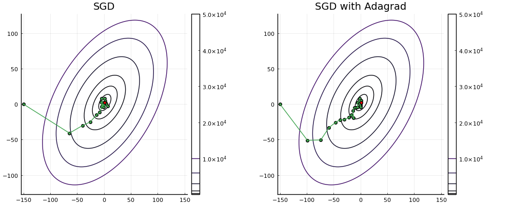

```julia
plot(plt,pltadagrad)
```

## RMSPROP

Con $0\leq \beta \leq 1$

\begin{align*} \pmb{\theta}_{t+1} & = \pmb{\theta}_{t} -\frac{ \eta\pmb{1} }{ \epsilon\pmb{1} + \sqrt{\pmb{v}_{t+1}} } \odot \pmb{g}\left( \pmb{\theta}_{t} \right) \\ \pmb{v}_{t+1} & = \beta\pmb{v}_t + (1-\beta)\pmb{g}\left( \pmb{\theta}_t \right)^2 \end{align*}

## Adam (Kingma & Ba 2014 - Adam: A method for stochastic optimization)

Con $0\leq \beta_1 \leq 1,\, 0\leq \beta_1 \leq 1$

\begin{align*} \pmb{\theta}_{t+1} & = \pmb{\theta}_{t} -\frac{ \eta\pmb{1} }{ \epsilon\pmb{1} + \sqrt{\hat{\pmb{v}}_{t+1}} } \odot \hat{\pmb{m}}_{t+1} \\ \\ \hat{\pmb{m}}_{t+1} & = \frac{\pmb{m}_{t+1} }{ 1-\beta_1^{t+1} } \\ \\ \hat{\pmb{v}}_{t+1} & = \frac{ \pmb{v}_{t+1} }{ 1-\beta_2^{t+1}} \\ \\ \pmb{m}_{t+1} & = \beta_1 \pmb{m}_t + (1-\beta_1)\pmb{g}\left( \pmb{\theta}_t \right) \\ \\ \pmb{v}_{t+1} & = \beta_2\pmb{v}_t + (1-\beta_2)\pmb{g}\left( \pmb{\theta}_t \right)^2 \end{align*}